# Week-3 ~ **[Strong and Weak Relationships](https://www.youtube.com/watch?v=1K0IR0IoDVI&list=PL3DBHamkNmfc2ApZFnxIwceBkFcLq0fCz&index=1)**

Worked on

- September 3rd, Saturday
- September 4th, Sunday

## Module-01: **[Introduction](https://youtu.be/1K0IR0IoDVI)**

on 3rd September, 2021 ~ Friday

Started with a short clip from the movie: **Harry potter and the Philosopher's Stone (2001), Directed by: Chris Columbus *(Based on Harry Potter by J.K. Rowling)*** in which...

> - Hagrid comes to take Harry Potter. He is perplexed, he is not sure who is this 8foot long person -- who knocks the door off and enters.
> - And when he asked, Who are you?, Why are you here?
> - Hagrid replies: Iam here to take you Hokwortz -- He doesn't even know what it is.. Its the school of Witchcraft and Wizadry and you are invited to come and join..

To put the theme of usage of it in this week..

> Hagrid comes to meet Harry potter and take him. And harry potter doesn't know him.

Pause for a min... and think... Is this what happens in a real life.. **Does opportunites come from those, whom we are not close.. or a really good friend..??**

-- 2 cases:

[figure not shown]

.. Well study says, the case-2. i.e., Most pople get opportunites from which whom they are not close with.. -- something called as **Weak-Tie** (Tie means FriendShip), A Weak Friendship...

[figure not shown]

i.e., say if you have 100 friends, you'll get opprortunity from the one, who is not a close friend, but an acquaitance --- **How's that..??**, that's what makes this week, come let's explore..

## Module-2: **[Granovetter's Strength of Weak ties](https://youtu.be/uE8pVkXEtT0)**

Assume I went to 100 people and asked them randomly, **You are working in this office, who told you about this job opportunity?**

> More than 90% will say that... **This person's friend who is my friend's friend... or someone to whom I was not close to him, told about this job.. etc...**, very rarely we encounter like.. said by my father..

[figure not shown]

- This might be counter-intuitive.... Is it like, our close friends don't want to say the job-opportunity??

[figure not shown]

  ...Not really..!! the following reason, makes convincible..
- Assume a scneario, you have 5 friends, 4 are of them are very close to you and all those are from same world(i.e., all those work in a same place). Whatever they know, even you know most of them..Ofcourse, occasionally may tell a new information.
- Now see the E's role (5th friend) here.., he is from different world together. Whatever he knows, you may not be getting from close friends.

[figure not shown]

  . This E's information, to which you are slightly aware of. So, he is the one who'll tell the information from his world, which increases your sample space of information, which A, B, C, D can't.
- Given that E is a distant friend of you, probably a weaker friendship with him. That's called as **Weak Tie**, and with the A,B, C, D its called **Strong Tie**

[figure not shown]

  .
- Strong ties are weak when it comes to telling a new job related information. And, Weak ties are strong in-terms of telling the new job opportunity, which will be of worth-knowing. Hence..

> **Weak** ties are actually **Strong**, while the **Strong** ties are actually **weak**.

**Historical Perspective..**..

- **Granovettor** in the late 1960s, conducted his experiment that: **From where do you got this job opportunity?**, and most of them replied **it was through Acquantainces**.
- That is when, he observed, something counter-intuitive is being heppening, and conducted experiments and concluded that **Strength of weak-ties is in play here** and tried publishing a paper in 1969 -- but the scientific community didn't accepted it, so got rejected.
- Later in 1973 people started accepting his vies , and it got accepted. Then after getting accepted, it became reslly really famous -- famous simply because, it is **Such an important concept yet very counter-intuitive**.

**MORAL**: Keep your acquantainces happy, you should not just treat your good friends. --*There is some fallacy here, if you started treating acaquaintances, then they become good friends and you may not get new information*.

So, the point is: You should have a big friend circle, your opportunites increase, but the new opprotunites come acquantinces for the above reasons listed.

So, now let's get familiar with the slightly abstract mathematical concepts around these..

## Module-3: **[Triads, Clustering coefficient & Neighborhood overlap](https://youtu.be/qSqSzzFdhSE)**

### **Triads and Triadic closure...**

-- Root-node is the person, and child-nodes are the people whom he is friend of. **NOTE:** Here child nodes doesn't know each other themselves directly.

[figure not shown]

.

Eventually one can expect that, those become friends each other.. then ..

[figure not shown]

.

- The structure is called a **Triad**, and the friendship that happens in this triad, making it a triangle -- this phenomenon is called the **Triadic closure**.
  - See, its Traid, becoems closed -- so Triadic Closure.

[figure not shown]

### **Clustering Coefficient**

\begin{align} \textbf{Clustering coefficient} = \frac{\textit{Existing friendships}}{\textit{Total possible friendships that can exist}} \end{align}

Consider 5 friends in 2 scenarios.. firstly, all of them not know them-selves, second all know themselves. Which one do you prefer *(to be the center-node in the graph)*..??

[figure not shown]

-- mostly second one. Ofcourse, in some scenarios, where the 1st might be favourable.

Let's try to quantify this matematically..!! there must be something in between these.. like some not being not-known to each...right..

> i.e.,.. Say you are friend with 5 people and there are some friendships between them selves. Now how many possible friendships can happen between these.. In 5 people, 4 chooses to be friends... how many ways one can do that..? 5 friends in 4 different ways: so $5 \cdot 4=20$ -- as we counted the SINGLE friendship TWICE(as from either-side), scale-down by half gives $ \frac {5 \cdot 4}{2}=\frac {20}{2}=10$.
- In the example, there are 6 friendships *(as represented in the figure, consider friendships among themselves, not including you[the center-node])*.

[figure not shown]

- The strength of friendships depends on the *friend ships between them*. The fraction $\frac{6}{10}$ denotes the strength of friendships with these 5 friends -- formally called as **Clustering Coefficient**.i.e.,

  > In ${Nr}$ place the friendships that are existing between them, in ${Dr}$, place the total no. of friendships that can exist between them.

If it is $1$, all know each other, if $0$, none of them know each other.

[figure not shown]

. In between, tells the strongness... nearer to 1, stronger, nearer to 0, weaker..

Why this is important..??

> It is observed that, people who've committed suicides, had very less clustering co-efficient.

[figure not shown]

> .  
> Its not that, those people had less friends, they had, but of different circles. Whenever they need to meet, they'll meet one and comes back.. not together as all those aren't known to themselves.

and in similar cases...

### **Neighborhood Overlap**

Term may seem bit complex, let's go with the right analogy...  
**How to judge a person..??** Is it based on.. *How much he earns..??*

- i.e., if A earns > than B, then A is richer than B.

[figure not shown]

Let's try redifining it.. by ot looking at the bank balance.. instead.. as

- In Dr, the earnings of person
- In Nr, to where the money is spent on good deeds

[figure not shown]

  > Then, if he spends ofr noble-causes, then I call as richest.

Now see.. the richness is got defined as.. **The proportion of money how well the money is spent divided by how much one ears**.  
**Why used fraction here....??**  
If the Dr is large and Nr is small - that gives a very less value *(closer to $0$)* -- then I don't call as rich, if equal, then it would be closer to $1$, then can call as rich.

[figure not shown]

Similarly.. **The strength of a friendship** can be defined as follows.... See the no.of common friends they had -- and designate it as their strength

or..

Look, what fraction of friends are common in between.

[figure not shown]

i.e., $$\textbf{Neighbourhood Overlap} = \frac{\text{# common friends}} {\text{# total friends}}$$. athematically speaking.. its.. $$\text{Neighbourhood Overlap} = \frac{A \cap B} {A \cup B}$$ If it is $\text{close to} 1 \text{Neighborhood Overlap is MAXimum}$, if $\text{close to} \text{Neighborhood Overlap is MINimum}$

## Module-4: **[Structure of Weak ties, bridges and local bridges](https://youtu.be/OguUuU8K9-I)**

Assume you are given a graph G, and asked to tell **What are the weak ties?**, Can you tell or can't?

[figure not shown]

Say you are given this graph.. the one *(Recollect the graph of week-1: Connectedness.. )*..

[figure not shown]

A and B are from two different islands, and those are friends, and they don't have any common friends in between..  
Then by definition it is the *Weak tie..* -- May say that, they can also be good friends.. -- this isn't possible for the reason:

> If they both are good friends, then B should have more friends than this and same for A too (because of triadic closure)

So, given that, triadic closure is not there-- is itself and indication that, it's a Weak tie. So in this.

[figure not shown]

-- that being only 1 edge is not possible in real life. So

[figure not shown]

, removal of such edge, the graph becomes disconnected. It is called a **Bridge.**

> A and B do not have any common friends, nor there is a path from A to B other than A to B.

**Local Bridge** *("Weak bridge" to remember intuitively)*  
[DEF]

> Its a bridge(an edge), without having any triads on either side of the vertices.

So, every bridge is a local bridge by definition..

[figure not shown]

-- here A-B is not a bridge but a local bridge.  
Such local bridges can also be termed as Weak ties -- reason: none of friends of A, B knows and same for B -- if they would have known, it would have became a triad right.

So, Granovetter observed that, this local bridges form the weak ties. *(And a weak tie is mostly a local bridge-- they both don't have a common friends)*  
So, he argued as: such weak ties connect A to a new world of B from where the good opportunities arise.

### Strong Triadic Closure property

Assume a friendship like..

[figure not shown]

.. Its intuitive that, Even *Raj* and *Ram* becomes friends (May or may not be the strong tie, but a tie). So, this results in the triadic closure due to the strong tie

[figure not shown]

-- (dotted line to denote, some tie) ---- which forms as **Strong triadic closure property**. pretty straight forward right...!!

Now (say) in the graph of

[figure not shown]

if A has 50 friends

[figure not shown]

.. and some of them are strong ties.  
based of Strong triadic closure property, .. there exists some tie between A and B

[figure not shown]

.  
This results in: A and B not being in local bridge -- why, now there exists a common friend for both, thus forms a triadic closure. *(Even as per definition of local bridge, presence of a triad violates it to be a local bridge)*.

To conclude..

> A local bridge is mostly a weak tie.

If there exists any triads *(between A and B)* due to strong ties of A, *(as like in above: via "Z")*, then that violates to be a local bridge. *(by definition and intuition)*.

## Module-5: **[Validation of Granovetter's experiment weak tie using Cellphone data](https://youtu.be/K5MzMPLNlnQ)**

In the time of 1960s (the years in which Granovetter conducted his experiments on weak ties), there wasn't much data that time.  
Now, the fact which is going to be revealed is **The local bridges turnout to be weak ties** which Granovetter couldn't show back then -- not clear.. read the below conducted experiment and read this again..

Now, due to this era, a lot of data exists. Im the year of 2007, there conducted an experiment using *Cell phone's data*, which is done s follows:

## Module-6: **[Embeddedness](https://youtu.be/ZMZqMbhSg28)**

Imagine a situation.. (Say) on a street.

> - You've met a person, and talked.... and soom became friends. Now if he suddenly asks for money, what's your immediatie reaction?

[figure not shown]

>   ... Who is this person, we just became friends, and doesn't know really well -- how can I trust him..?? _(May be its a genuine request, but you don't)_
> - What if that person you've met turned out to be an old friend. Then you would have given him, because of duration which built trust.

[figure not shown]

>   -- there is still 1 more reason, which gets revealed in further discussion of lecture --- its the

**Embeddedness**

It can be defined as follows..

> Embeddedness between two friends is defined as the no. of common friends in betwee. *(Yes..!! We sae the siimilar ones in the past like neighborood overlap... but this is most pretty well studied in social-sciences literature)*.

[figure not shown]

Where they observed that **If there is high embeddedness -- its a strong relationship**.

In the above example, (for the first person), the embeddedness(#common friends) was zero -- ie., no common friends.  
Now, imagine that, suddenly in talk, he reminds your one of the good friend, and he is friend to hi -- then you probably would have trusted, and you may started to take the decision of giving money.

> See that, the trust increased by many folds due to the embeddedness(no. of common friends).

And say, if said 5 common friends, then you realize that he is not cheating you, and you feel some trust in him.

$$\text{Embeddedness} \propto \text{Trust}$$

let's see why this is true, with some examples..

> You wen to bank for a loan, then the bank manager expects for the guarantee.. If in case you become the defaulter, he can ask the other one.

Similar situation arises in friendship too..If had common friends in both, the chances of cheating are less -- why this is true..??  
If in case the do, then the common friends come in between to resolve it. And atleast in fear of so many friends they may not cheat.  
If had no common friends, then there are no one to pull in.

-- So all these psychological factors come in place.. having more common friends means more trust and vice-versa.

Do you think every single relationship should have *High embeddedness*? (**Embeddedness** means: Its not w.r.t. a person(a node), its a person's friend ship with another (an edge))

> Answer is: Yes and No.  
> Yes because: above reasons like *Trust*, *Relation becomes stronger*  
> No because: Not always the high embeddedness is good. -- How..? Why..?? coming up next... *(Structural Holes)*

## Module-7: **[Structural Holes](https://youtu.be/-5oW-EUmhf4)**

Say, there are two friends, and they have many common friends -- means more trust - means less chance of cheating..!

[figure not shown]

Now, you and other friend -- no common friends in between.

[figure not shown]

.. if present inany structures like Business, Money transaction... intuitively.. some danger may happend (may not be.. always true).

**Will this be of any advantageous..??** -- Yes, Why..? look at the community..

[figure not shown]

> Two communities are different. And if Sudarshan(sir) has to reach out to the other community, can only go via Ramya  
> Now, if the sir would like to buy a house, then sir, need to knly consult Ramya, because she is the only known one to the community (Say that, sir doesn't know any other) -- here she *Monopolises..* due to Zero Embeddedness.  
> Now, this becomes a huge advantage for Ramya, harnessing the fact that sir doesn't know anyone in that commnunity (If known, it affects her business)-- *this is similar to the Granovetter's Theory of Weak ties, she is the connection to a new world.*  
> Have you noticed the **Structural hole** inthe graph..?? i.e., Any one to reach from L.H.S. community to R.H.S. need to pass only by long chain -- any friend of Sudarshan(sir) then to Ramya, then to other community.

[figure not shown]

So, high embeddedness in the case of personal friendship -- builds trust  
When had structural holes like above, people like Ramya, benefits from it.

## Module-8: **[Social Captial](https://youtu.be/LgxSp2G-mGA)**

Consider facebook, say it wants to become even more popular. So for a one to stick to to it..(ah..hh..!!), one's newsfeed should be filled with a lot of content and that should be interesting. When you get this..?? When had similar kind of interested people..or they had something excited to share..

[figure not shown]

With this in mind, facebook wants to ensure that, you not only make friends randomly, but to those of similar interest. Every person can _maintain_ limited no. of friends, so they should be of similar interest.

Say, you have 100 nodes, and you need to sprinkle 500 edges. Where exactly will he put edges..?  
This becomes Social Capital. You want to make a network and you get a atmost benefit from it.

[figure not shown]

. For the companies like FaceBook, its the lot of attention on their UI. **** Consider another example..  
There are a set of 20 employees (and you are the CEO). There exists 2 pairs of people with some disturbances/fighting. As matter of resolving, you can try out like, give some money(budget) and tell them to go for a lunch and bond up.. or for a theme park, go and play and bond up.. -- so that you create captial out of it. (Here, you may expect like, all to be a good team)

Sometimes, the social network is itself the capital.  
Nomination works well due to the complex structure in the social networks which is giving better productivity.

How to maximize it..?? -- is an open question. i.e., its not easy to tell that some protocol works...  
As an example, there are bunch of friends (say 1000), all are friends with each other.. Is there any fun in playing football with groups of 2 teams..?? (If one person had two children and they are playin chess. Now to whom should the person cheer for..?? When loved equally, how can one cheer for one side.. to make other person lose) -- there has to be two communities right..(where a lot of love is within and not across)

[figure not shown]

-- so that, can form two teams and play. -- So, 100% unity here is boring..  
Here comes two terms:

**Closure**

A friend's friend should become friend.

[figure not shown]

... This cascades, and every body is friend with another_

[figure not shown]

-- this way there is no fun

**vs**

**Brokerage**

There should be an edge (a sort of local bridge), like the above module's example. ---i.e,. There should be some strucutral holes too.

[figure not shown]

So, Closure is important and Brokerage is also important *to have the communication to other community*.

If given a 100 nodes and asked how would you sprinkle some edges to yield maximum benefit..?? *that's a tough question to answer, still research is going on -- because its not still well understood **What should be the exact structure?***

## Module-9: [**Finding Communities in a graph _(Brute Force Method)_**](https://youtu.be/ncQMJmHe7Mw)

In this module, we are going to divide the whole graph into two communities(groups) -- in a brute force manner, and check with of those divisions are best.  
How do we check that.... as per the definition of communites..

**The nodes which are part of a community, will have more no. of edges with other nodes in the same community and less with other community.**

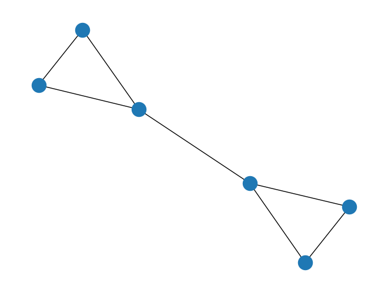

```python
import networkx as nx
import matplotlib.pyplot as plt

nx.draw(nx.barbell_graph(3, 0))
plt.show()
```

```python
nx.barbell_graph?
```

```
Signature: nx.barbell_graph(m1, m2, create_using=None)
Docstring:
Returns the Barbell Graph: two complete graphs connected by a path.

For $m1 > 1$ and $m2 >= 0$.

Two identical complete graphs $K_{m1}$ form the left and right bells,
and are connected by a path $P_{m2}$.

The `2*m1+m2`  nodes are numbered
    `0, ..., m1-1` for the left barbell,
    `m1, ..., m1+m2-1` for the path,
    and `m1+m2, ..., 2*m1+m2-1` for the right barbell.

The 3 subgraphs are joined via the edges `(m1-1, m1)` and
`(m1+m2-1, m1+m2)`. If `m2=0`, this is merely two complete
graphs joined together.

This graph is an extremal example in David Aldous
and Jim Fill's e-text on Random Walks on Graphs.
File:      ~/anaconda3/envs/Python-R/lib/python3.8/site-packages/networkx/generators/classic.py
Type:      function
```

```python
G = nx.barbell_graph(4, 0)
nodes = G.nodes()
n = G.number_of_nodes()
```

Flow goes as: (Trying all possiblities is goes as below..)

> 1st community having 1 node, then 2nd -> n-1 and all its possiblites  
> Then 1st having 2 nodes, then 2nd will have n-2.. so on.. -- *need to check all those possiblities*  
> Here a P2N: If could find the nodes which fall in the 1st community, then the rest will be of 2nd community -- so, our aim goes like: Get all the combination of nodes that fall in the 1st community.

**How do we get the combinations..??**

> via the package `itertools` (look out some test below.. )

```python
import itertools
```

```python
itertools.combinations?
```

```
Init signature: itertools.combinations(iterable, r)
Docstring:
Return successive r-length combinations of elements in the iterable.

combinations(range(4), 3) --> (0,1,2), (0,1,3), (0,2,3), (1,2,3)
Type:           type
Subclasses:
```

```python
itertools.combinations([2, 3, 4, 5, 6, 7], 3)
```

```
<itertools.combinations at 0x7fe7adeb3f90>
```